# Breast Cancer Data Analysis

Jagadish Rao

12/18/2021

## Introduction

This analysis project is the culmination and final requirement of the **Google Data Analytics Professional Certificate**. It aims to utilize the learning and best practices taught in the course. A sincere ‘Thank You’ to all my instructors, it was a great, well designed course.

Cancer needs no introduction as a disease that inflicts its pain, suffering, leading to disfigurement and eventual death if not detected and treated early. Unfortunately, the early signs and symptoms of the disease and its progress are often neglected, missed or masked by other diseases. Female breast cancer is a silent killer that can strike anytime, so knowing and proactively acting on the disease patterns is critical.

The identification of breast cancer trends in the USA has been selected for this project. This analysis is approached from a data analytics perspective and has no claims to being a substitute or auxiliary to a professional medical study or advice.

## Analysis Objectives

There are many open questions that this analysis seeks to answer:

- Does cancer rate vary by geographical location
- Does race play a part
- Does increasing age lead to a higher risk
- Is there a relationship between race and age as related to cancer risk

## Raw Data

United States Cancer Statistics - Incidence: 1999 - 2018, WONDER Online Database. United States Department of Health and Human Services, Centers for Disease Control and Prevention and National Cancer Institute; 2021.

Dataset: United States and Puerto Rico Cancer Statistics, 1999-2018 Incidence

https://wonder.cdc.gov/cancer-v2018.HTML

Query Parameters:  
Age Groups: 10-14 years; 15-19 years; 20-24 years; 25-29 years; 30-34 years; 35-39 years; 40-44 years; 45-49 years; 50-54 years; 55-59 years; 60-64 years ; 65-69 years; 70-74 years; 75-79 years; 80-84 years; 85+ years  
Cancer Sites: Female Breast  
Race: American Indian or Alaska Native; Asian or Pacific Islander; Black or African American; White  
Sex: Female  
States: Alabama (01); Alaska (02); Arizona (04); Arkansas (05); California (06); Colorado (08); Connecticut (09); Delaware (10); District of Columbia (11); Florida (12); Georgia (13); Hawaii (15); Idaho (16); Illinois (17); Indiana (18); Iowa (19); Kansas (20); Kentucky (21); Louisiana (22); Maine (23); Maryland (24); Massachusetts (25); Michigan (26); Minnesota (27); Mississippi (28); Missouri (29); Montana (30); Nebraska (31); Nevada (32); New Hampshire (33); New Jersey (34); New Mexico (35); New York (36); North Carolina (37); North Dakota (38); Ohio (39); Oklahoma (40); Oregon (41); Pennsylvania (42); Rhode Island (44); South Carolina (45); South Dakota (46); Tennessee (47); Texas (48); Utah (49); Vermont (50); Virginia (51); Washington (53); West Virginia (54); Wisconsin (55); Wyoming (56)  
Year: 2000; 2001; 2002; 2003; 2004; 2005; 2006; 2007; 2008; 2009; 2010; 2011; 2012; 2013; 2014; 2015; 2016; 2017; 2018  
Group By: Cancer Sites; States; Year; Race; Age Groups  
Calculate Rates Per: 100,000  
Standard Population: 2000 U.S. Std. Million

Cancer incidence (rate) data is standardized to a population of 100k.  
Data is not available if the rate is less than 16.

The raw data was downloaded in four separate text data files due to CDC site download size restrictions. The downloaded files were then renamed to more user friendly titles.

- breast_cancer_2000_2004.txt
- breast_cancer_2005_2009.txt
- breast_cancer_2010_2013.txt
- breast_cancer_2014_2018.txt

## Tools

Language: R

Environment: RStudio 2021.09.1+372 “Ghost Orchid” Release (8b9ced188245155642d024aa3630363df611088a, 2021-11-08) for macOS

## Data Organization

The downloaded raw data files are tab delimited text files with Header.

The four raw data files are located in a sub folder named “data”.

## Processing and Analysis

##### R packages Load

```r
library(tidyverse)
library(here)
library(janitor)
library(skimr)
library(validate)
library(usmap)
```

##### Raw data Read

```r
bcdata_2000_2004 <- read.delim(here("data", "breast_cancer_2000_2004.txt"))
bcdata_2005_2009 <- read.delim(here("data", "breast_cancer_2005_2009.txt"))
bcdata_2010_2013 <- read.delim(here("data", "breast_cancer_2010_2013.txt"))
bcdata_2014_2018 <- read.delim(here("data", "breast_cancer_2014_2018.txt"))
```

##### Raw data Merge

```r
bcdata <- bind_rows(bcdata_2000_2004, bcdata_2005_2009, bcdata_2010_2013, bcdata_2014_2018)
```

##### Column names to lowercase

```r
bcdata <- clean_names(bcdata)
```

##### Columns selection for analysis

```r
bcdata <- bcdata %>%
  select(states, year, race, age_groups_code, count)
```

##### Columns rename for clarity

```r
bcdata <- bcdata %>%
  rename(state = states, age_grp = age_groups_code, count_100k = count)
```

At this point, all the data has been loaded, relevant columns selected and renamed.

##### Data Checking

```r
skim(bcdata)
```

Data summary

| Name | bcdata |
| --- | --- |
| Number of rows | 18745 |
| Number of columns | 5 |
| _______________________ |  |
| Column type frequency: |  |
| character | 3 |
| numeric | 2 |
| ________________________ |  |
| Group variables | None |

**Variable type: character**

| skim_variable | n_missing | complete_rate | min | max | empty | n_unique | whitespace |
| --- | --- | --- | --- | --- | --- | --- | --- |
| state | 0 | 1 | 0 | 20 | 280 | 52 | 0 |
| race | 0 | 1 | 0 | 32 | 280 | 5 | 0 |
| age_grp | 0 | 1 | 0 | 5 | 280 | 15 | 0 |

**Variable type: numeric**

| skim_variable | n_missing | complete_rate | mean | sd | p0 | p25 | p50 | p75 | p100 | hist |
| --- | --- | --- | --- | --- | --- | --- | --- | --- | --- | --- |
| year | 280 | 0.99 | 2009.32 | 5.45 | 2000 | 2005 | 2009 | 2014 | 2018 | ▇▇▆▇▇ |
| count_100k | 280 | 0.99 | 220.95 | 320.34 | 16 | 42 | 102 | 258 | 3102 | ▇▁▁▁▁ |

```r
tabyl(bcdata, state, year)
```

| state | 2000 | 2001 | 2002 | 2003 | 2004 | 2005 | 2006 | 2007 | 2008 | 2009 | 2010 | 2011 | 2012 | 2013 | 2014 | 2015 | 2016 | 2017 | 2018 | NA_ |
| --- | --- | --- | --- | --- | --- | --- | --- | --- | --- | --- | --- | --- | --- | --- | --- | --- | --- | --- | --- | --- |
|  | 0 | 0 | 0 | 0 | 0 | 0 | 0 | 0 | 0 | 0 | 0 | 0 | 0 | 0 | 0 | 0 | 0 | 0 | 0 | 280 |
| Alabama | 23 | 24 | 23 | 24 | 24 | 23 | 24 | 23 | 24 | 23 | 23 | 24 | 24 | 25 | 24 | 24 | 24 | 25 | 23 | 0 |
| Alaska | 8 | 7 | 5 | 7 | 6 | 8 | 7 | 7 | 8 | 7 | 8 | 9 | 9 | 6 | 9 | 9 | 8 | 9 | 8 | 0 |
| Arizona | 12 | 13 | 12 | 12 | 12 | 13 | 12 | 13 | 15 | 13 | 17 | 17 | 14 | 18 | 21 | 20 | 19 | 21 | 19 | 0 |
| Arkansas | 0 | 17 | 19 | 18 | 18 | 18 | 16 | 18 | 18 | 18 | 20 | 18 | 20 | 21 | 19 | 19 | 20 | 20 | 20 | 0 |
| California | 38 | 37 | 37 | 40 | 38 | 37 | 38 | 41 | 40 | 40 | 41 | 41 | 42 | 41 | 45 | 41 | 41 | 41 | 43 | 0 |
| Colorado | 12 | 12 | 13 | 12 | 12 | 12 | 12 | 14 | 13 | 16 | 15 | 12 | 16 | 16 | 14 | 15 | 16 | 17 | 17 | 0 |
| Connecticut | 14 | 17 | 19 | 17 | 17 | 18 | 18 | 18 | 18 | 19 | 17 | 19 | 19 | 20 | 19 | 20 | 18 | 21 | 21 | 0 |
| Delaware | 11 | 10 | 10 | 11 | 13 | 12 | 11 | 13 | 13 | 13 | 13 | 13 | 12 | 14 | 16 | 15 | 16 | 15 | 16 | 0 |
| District of Columbia | 16 | 12 | 14 | 15 | 11 | 11 | 12 | 12 | 13 | 15 | 12 | 14 | 13 | 13 | 13 | 13 | 13 | 15 | 12 | 0 |

[output cut: 42 more lines]

```r
tabyl(bcdata, state, age_grp)
```

| state | 20-24 | 25-29 | 30-34 | 35-39 | 40-44 | 45-49 | 50-54 | 55-59 | 60-64 | 65-69 | 70-74 | 75-79 | 80-84 | 85+ | emptystring_ |
| --- | --- | --- | --- | --- | --- | --- | --- | --- | --- | --- | --- | --- | --- | --- | --- |
|  | 0 | 0 | 0 | 0 | 0 | 0 | 0 | 0 | 0 | 0 | 0 | 0 | 0 | 0 | 280 |
| Alabama | 0 | 2 | 31 | 38 | 38 | 38 | 38 | 38 | 38 | 38 | 38 | 38 | 38 | 38 | 0 |
| Alaska | 0 | 0 | 0 | 0 | 16 | 19 | 20 | 19 | 20 | 19 | 16 | 13 | 3 | 0 | 0 |
| Arizona | 0 | 6 | 19 | 19 | 22 | 31 | 29 | 29 | 33 | 28 | 20 | 19 | 19 | 19 | 0 |
| Arkansas | 0 | 0 | 15 | 20 | 34 | 36 | 36 | 35 | 35 | 32 | 31 | 23 | 19 | 21 | 0 |
| California | 5 | 32 | 57 | 57 | 57 | 60 | 65 | 66 | 66 | 64 | 62 | 57 | 57 | 57 | 0 |
| Colorado | 0 | 8 | 19 | 19 | 19 | 26 | 26 | 26 | 24 | 23 | 19 | 19 | 19 | 19 | 0 |
| Connecticut | 0 | 0 | 19 | 19 | 33 | 39 | 36 | 37 | 37 | 34 | 30 | 27 | 19 | 19 | 0 |
| Delaware | 0 | 0 | 0 | 6 | 20 | 27 | 32 | 28 | 29 | 25 | 23 | 19 | 19 | 19 | 0 |
| District of Columbia | 0 | 0 | 0 | 0 | 17 | 26 | 32 | 31 | 33 | 33 | 28 | 22 | 16 | 11 | 0 |

[output cut: 42 more lines]

```r
tabyl(bcdata, state, race)
```

| state | American Indian or Alaska Native | Asian or Pacific Islander | Black or African American | White | emptystring_ |
| --- | --- | --- | --- | --- | --- |
|  | 0 | 0 | 0 | 0 | 280 |
| Alabama | 0 | 0 | 221 | 230 | 0 |
| Alaska | 2 | 0 | 0 | 143 | 0 |
| Arizona | 7 | 14 | 38 | 234 | 0 |
| Arkansas | 0 | 0 | 124 | 213 | 0 |
| California | 41 | 239 | 230 | 252 | 0 |
| Colorado | 0 | 7 | 23 | 236 | 0 |
| Connecticut | 0 | 2 | 119 | 228 | 0 |
| Delaware | 0 | 0 | 51 | 196 | 0 |
| District of Columbia | 0 | 0 | 172 | 77 | 0 |

[output cut: 42 more lines]

```r
#create data validation rules
rules <- validator(state != "",
  year >= 2000,
  year <= 2018,
  race != "",
  age_grp != "",
  count_100k >= 0)

# verify data using rules
confront(bcdata, rules)
```

```
## Object of class 'validation'
## Call:
##     confront(dat = bcdata, x = rules)
##
## Rules confronted: 6
##    With fails   : 3
##    With missings: 3
##    Threw warning: 0
##    Threw error  : 0
```

```r
# The above data checking shows that:
# Arkansas is missing data for year 2000
# Mississippi is missing data for year 2000-2002
# Nevada is missing data for year 2018
# South Dakota is missing data for year 2000
# age_group 20-24 is missing data for almost all (48) states
# Race - American Indian or Alaska Native is missing data for most states (42), as expected

# For an unbiased analysis -
# Remove data for all states for years 2000-2002, 2018
# Remove data for age_group 20-24
bcdata <- bcdata %>%
  filter(year %in%  c(2003:2017),
         age_grp != "20-24")

# Verify that no more errors
confront(bcdata, rules)
```

```
## Object of class 'validation'
## Call:
##     confront(dat = bcdata, x = rules)
##
## Rules confronted: 6
##    With fails   : 0
##    With missings: 0
##    Threw warning: 0
##    Threw error  : 0
```

##### Save the cleaned data set

```r
write_csv(bcdata, here("data", "bcdata.csv"))
```

## Data Analysis

### Cancer distribution by State

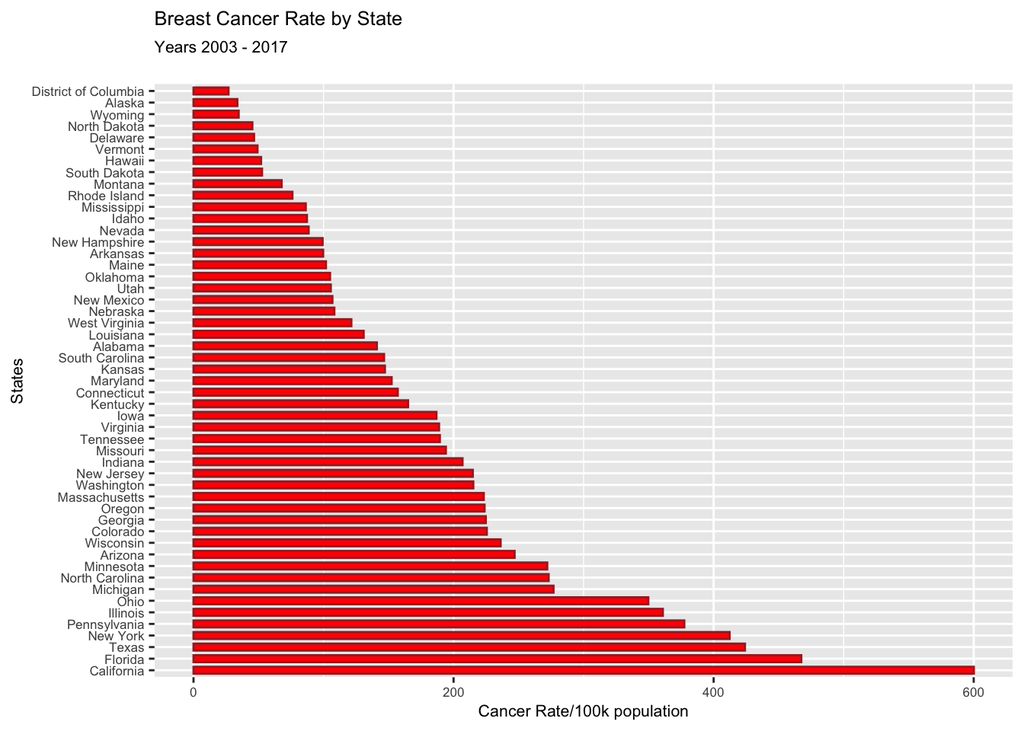

```r
# find the mean cancer rate per state
bcdata_state_mean <-
  bcdata %>%
  group_by(state) %>%
  summarise(state_mean = mean(count_100k))

# plot a column graph
bcdata_state_mean %>%
  ggplot(aes(x = state_mean, y = reorder(state, -state_mean)))  +
  geom_col(color = "brown", fill="red", width = 0.6) +
  theme(text = element_text(size = 8)) +
  xlab("Cancer Rate/100k population") +
  ylab("States") +
  labs(title = "Breast Cancer Rate by State", subtitle = "Years 2003 - 2017\n")
```

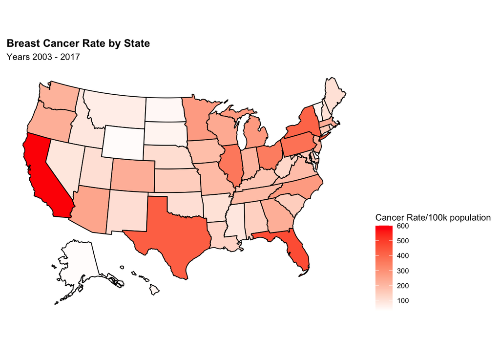

```r
# plot a map
plot_usmap(data = bcdata_state_mean, regions = "states", values = "state_mean") +
  scale_fill_continuous(name = "Cancer Rate/100k population", low = "white", high = "red") +
  theme(legend.position = "right") +
  labs(title = "Breast Cancer Rate by State", subtitle = "Years 2003 - 2017") +
  theme(plot.title = element_text(face="bold"))
```

### Cancer distribution by Race

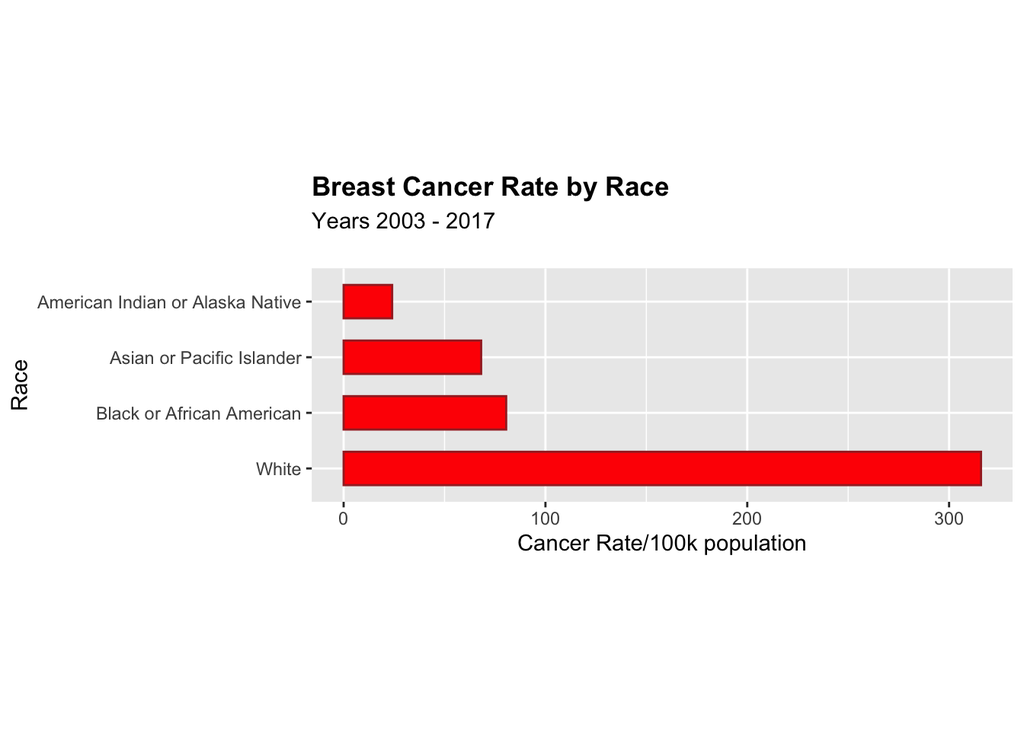

```r
# plot of cancer rate by race
bcdata %>%
  group_by(race) %>%
  summarise(race_rate = mean(count_100k)) %>%
  ggplot(aes(x = race_rate, y = reorder(race, -race_rate)))  +
  geom_col(color = "brown", fill="red", width = 0.6) +
  theme(aspect.ratio = 1/3)  +
  xlab("Cancer Rate/100k population") +
  ylab("Race") +
  labs(title = "Breast Cancer Rate by Race", subtitle = "Years 2003 - 2017\n") +
  theme(plot.title = element_text(face="bold"))
```

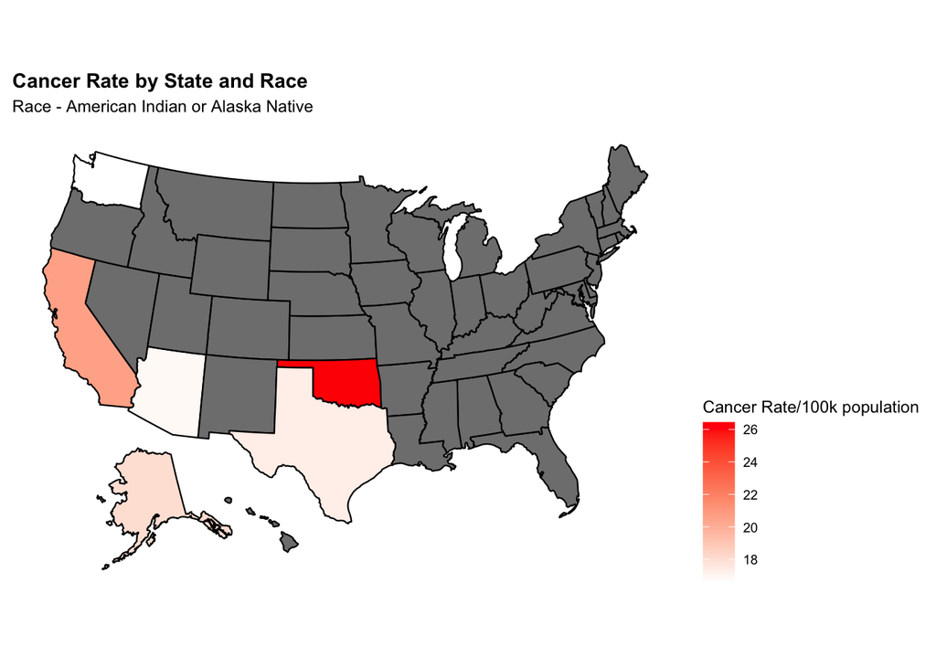

```r
# find the mean cancer rate by Race
bcdata_race <-
  bcdata %>%
  group_by(race, state) %>%
  summarise(race_mean = mean(count_100k))

# plot race = American Indian
bcdata_race_type <- bcdata_race %>%
  filter(race == "American Indian or Alaska Native")

# plot a map
plot_usmap(data = bcdata_race_type, regions = "states", values = "race_mean") +
  scale_fill_continuous(name = "Cancer Rate/100k population", low = "white", high = "red") +
  theme(legend.position = "right") +
  labs(title = "Cancer Rate by State and Race", subtitle = "Race - American Indian or Alaska Native") +
  theme(plot.title = element_text(face="bold"))
```

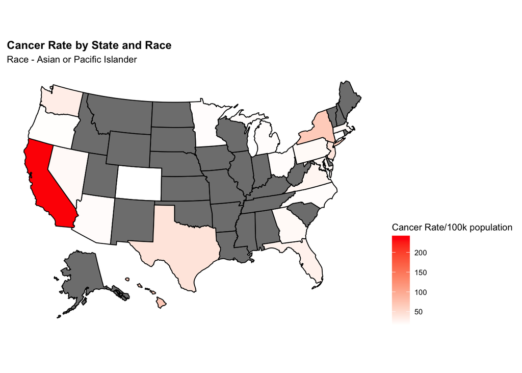

```r
# plot race = Asian or Pacific Islander
bcdata_race_type <- bcdata_race %>%
  filter(race == "Asian or Pacific Islander")

# plot a map
plot_usmap(data = bcdata_race_type, regions = "states", values = "race_mean") +
  scale_fill_continuous(name = "Cancer Rate/100k population", low = "white", high = "red") +
  theme(legend.position = "right") +
  labs(title = "Cancer Rate by State and Race", subtitle = "Race - Asian or Pacific Islander") +
  theme(plot.title = element_text(face="bold"))
```

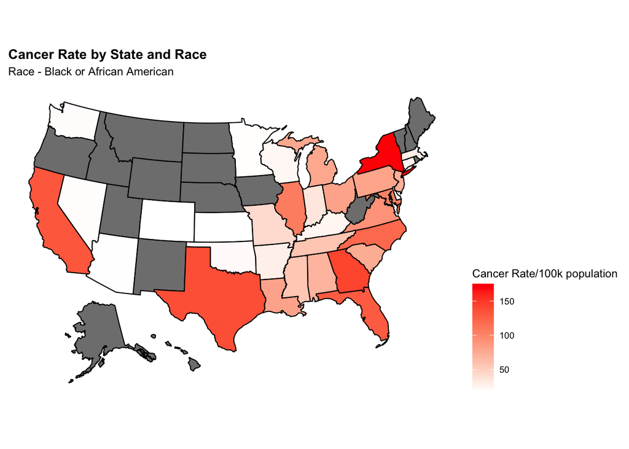

```r
# plot race = Black or African American
bcdata_race_type <- bcdata_race %>%
  filter(race == "Black or African American")

# plot a map
plot_usmap(data = bcdata_race_type, regions = "states", values = "race_mean") +
  scale_fill_continuous(name = "Cancer Rate/100k population", low = "white", high = "red") +
  theme(legend.position = "right") +
  labs(title = "Cancer Rate by State and Race", subtitle = "Race - Black or African American") +
  theme(plot.title = element_text(face="bold"))
```

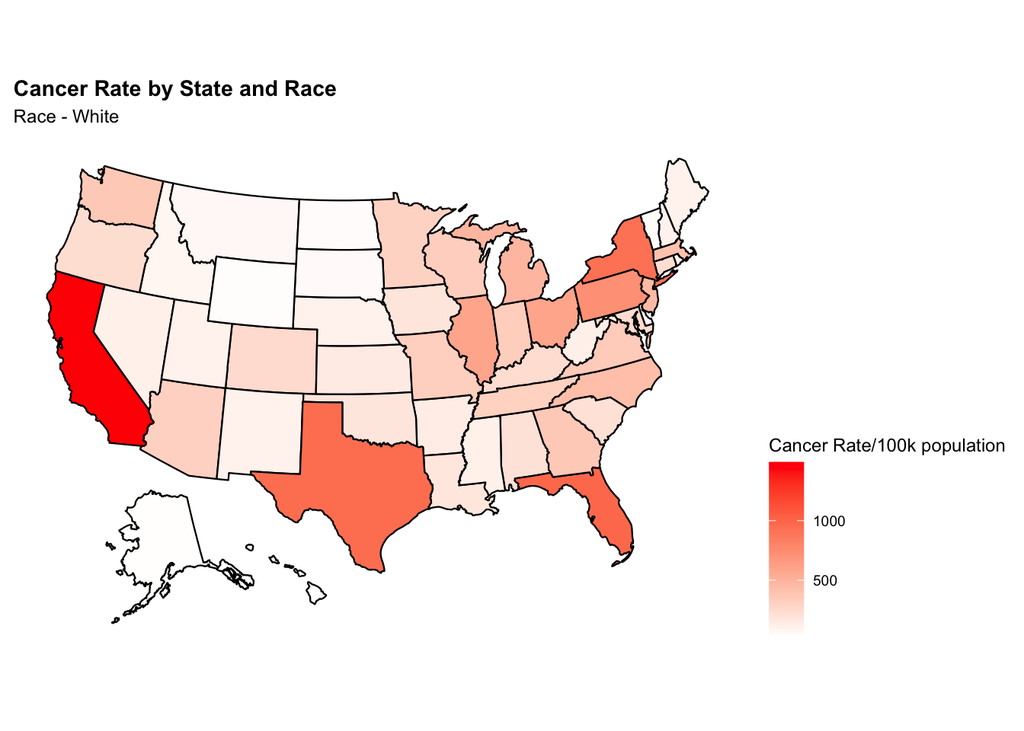

```r
# plot race = White
bcdata_race_type <- bcdata_race %>%
  filter(race == "White")

# plot a map
plot_usmap(data = bcdata_race_type, regions = "states", values = "race_mean") +
  scale_fill_continuous(name = "Cancer Rate/100k population", low = "white", high = "red") +
  theme(legend.position = "right") +
  labs(title = "Cancer Rate by State and Race", subtitle = "Race - White") +
  theme(plot.title = element_text(face="bold"))
```

### Cancer Distribution by Age Group

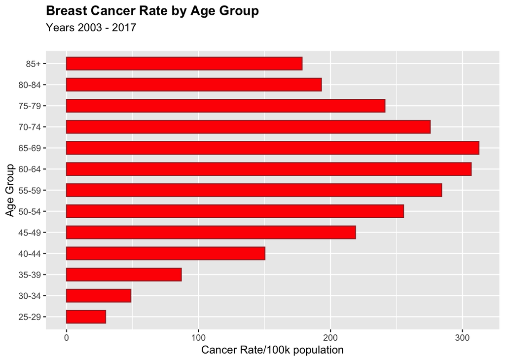

```r
bcdata_age_grp_mean <-
  bcdata %>%
  group_by(age_grp) %>%
  summarise(age_grp_rate = mean(count_100k))

# plot the graph
bcdata_age_grp_mean  %>%
  ggplot(aes(x = age_grp_rate, y = age_grp))  +
  geom_col(color = "brown", fill="red", width = 0.6) +
  xlab("Cancer Rate/100k population") +
  ylab("Age Group") +
  labs(title = "Breast Cancer Rate by Age Group", subtitle = "Years 2003 - 2017\n") +
  theme(plot.title = element_text(face="bold"))
```

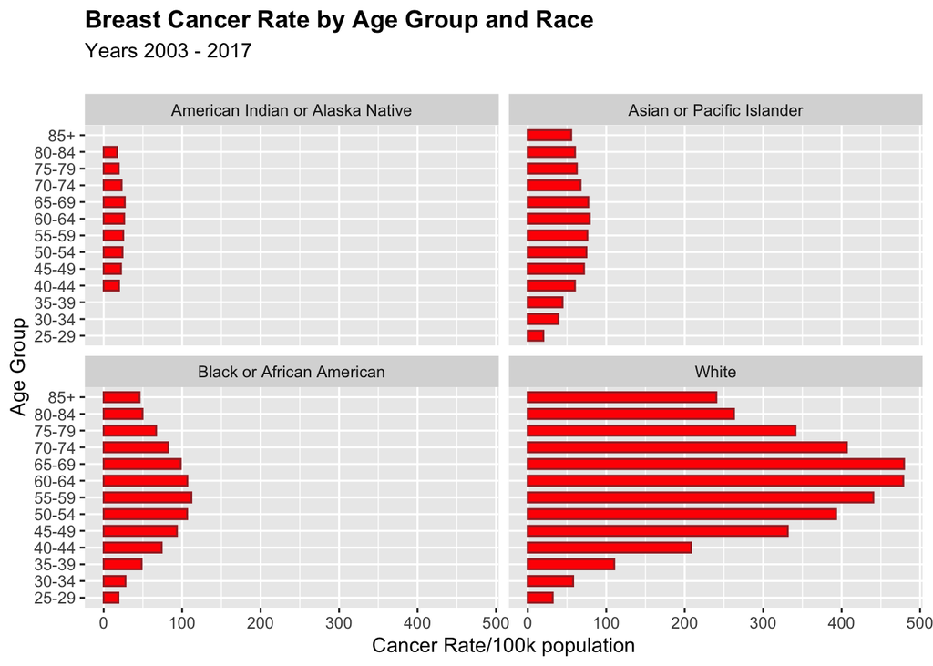

```r
bcdata %>%
  group_by(age_grp, race) %>%
  summarise(age_grp_rate = mean(count_100k)) %>%
  ggplot(aes(x = age_grp_rate, y = age_grp))  +
  geom_col(color = "brown", fill="red", width = 0.6) +
  xlab("Cancer Rate/100k population") +
  ylab("Age Group") +
  labs(title = "Breast Cancer Rate by Age Group and Race", subtitle = "Years 2003 - 2017\n") +
  theme(plot.title = element_text(face="bold")) +
  facet_wrap(~race)
```

## Conclusions

Cancer incidence rate variations are also likely due to certain factors not addressed by this analysis.

1. Better access to medical care (Doctor/Hospital to population ratio) that leads to a higher detection/incidence rate
2. Dietary choices
3. Income levels that afford access to medical care or restrict it
4. Awareness and motivation for regular breast cancer screening

To summarise, there are numerous factors, many of which are outside the scope of this analysis that play a part in predicting a breast cancer probability. The variables used in this analysis are historical statistics that only serve as trend indicators and merit deeper scientific scrutiny with relevent datasets.